# Suggested workflow using ethnobotanyR

Cory Whitney

2019-09-27

# ethnobotanyR

[figure not shown]

## Addressing issues of relevance to communities

Ethnobotany work often concerns people who are faced with uncertain decisions about how to manage natural resources. Trade-offs often have to be made between benefits for the natural world and for human development. These trade-offs should be discussed and the detriments to either human society or ecology should be mitigated. Our work in ethnobotany can help to make these trade-offs clear and help to support decision making so that it has the best outcomes for society and the natural world. Ideally the research that we do in ethnobotany should aim to have direct relevance to the human and natural communities that are involved. Well formulated research agendas in ethnobotany are those that seek to provide clarity for relevant and timely decisions and have been generated together with local people. We can better serve the world if our ethnobotany work is done with, rather than about, local communities.

The best way to make sure that our work is of direct relevance to communities is to start our process with local people, rather than developing our research agenda at our desks we should do it cooperatively with the broad interests of local communities in mind.

In addition to working closely with communities and generating quality research questions, another, possibly equally important part of ethnobotany is that we are good practitioners. This means attaining as much as possible a mastery of the tools needed for the job. This workflow gives a general overview of one possible process for an ethnobotany study and the tools that may be needed.

## Testing various hypotheses in ethnobotany

Users are highly encouraged to familiarize themselves with ethnobotany theory (Gaoue et al. 2017) and social ecological theory (Albuquerque et al. 2019). An overview of this theorhetical background will be helpful in understanding approaches in ethnobotany and formulating useful research questions.

## Getting Species names right

A large part of the work of ethnobotany is identification of species. Plant species names change all the time. As botanists learn more about the diversity of plant life the taxonomic record becomes more clear and different species groups are often split or merged. These changes are most accurately, and most timely, displayed on [The Plant List (TPL)](http://www.theplantlist.org/) maintained by the Missouri Botanical Garden.

Among the many other functions, the R package Taxonstand can cross-check .csv based lists of species names against the database (Cayuela, Stein, and Oksanen 2017). Here is an example using just the species names `Full.name` in Taxonstand’s `bryophytes` data.

First six rows of Taxonstand’s bryophytes species list

| x |
| --- |
| Acaulon triquetrum |
| Aloina aloides var. ambigua |
| Amblystegium confervoides |
| Amblystegium elodes |
| Anastrophyllum minutum |
| Aschisma carniolicum var. speciosum |

We run the `TPL()` function on just the species names `Full.name` in Taxonstand’s bryophytes data, i.e. Taxonstand::TPL(bryophytes$Full.name). The use of this package requires a good internet connection (over 700 kb/second) to connect to the TPL server.

First six rows of corrections of Taxonstand’s bryophytes species list with Genus species and authority

| New.Genus | New.Species | New.Authority |
| --- | --- | --- |
| Acaulon | triquetrum | (Spruce) Müll. Hal. |
| Aloina | aloides | (Bruch & Schimp.) E.J. Craig |
| Platydictya | confervoides | (Brid.) H.A. Crum |
| Campylium | elodes | (Lindb.) Kindb. |
| Anastrophyllum | minutum | (Schreb.) R.M. Schust. |
| Aschisma | carniolicum | (F. Weber & D. Mohr) Lindb. |

## Ordination methods

Analyses such as Detrended correspondence analysis (DCA) and Principal component analysis (PCA) may be useful for exploratory analysis of ethnobotany data. Such analyses should be used with caution and within the confines of the predetermined research aims and objectives.

### Detrended correspondence analysis (DCA)

Detrended correspondence analysis (DCA) can be used to find the main factors or ‘gradients’ in large and sparse community datasets. This can be a useful tool for assessing important informant-species-use associations in ethnobotany. Here we use the dataset presented in `eb_data` to perform DCA using the `decorana()` function in the `vegan` package (Oksanen et al. 2019).

The first step is to remove zero value row sums. The DCA can only work with data that is complete (i.e. we remove all NA cases as well as those where the species is listed by an informant but no specific use is recorded). This can be done quickly using the `select()` and `filter_all()` functions of the `dplyr` package (Wickham et al. 2019) and pipe `%>%` functions of the `magrittr` package (Bache and Wickham 2014).

```r
#create ethnobotany data (as in all function examples)
eb_data <- data.frame(replicate(10,sample(0:1,20,rep=TRUE)))
names(eb_data) <- gsub(x = names(eb_data), pattern = "X", replacement = "Use_")
eb_data$informant <- sample(c('User_1', 'User_2', 'User_3'), 20, replace=TRUE)
eb_data$sp_name <- sample(c('sp_1', 'sp_2', 'sp_3', 'sp_4'), 20, replace=TRUE)

#remove rows with zero rowsums
ethno_data_complete <- eb_data %>%
  dplyr::select(-informant, -sp_name) %>%
  dplyr::filter_all(any_vars(!is.na(.)))%>%
    dplyr::filter_all(any_vars(. != 0))
```

Use the `decorana` function of the `vegan` package to get the ordination results.

```r
#Save ordination results
 ethno_ordination <- vegan::decorana(ethno_data_complete)
```

Ordination results can be shown with the command `summary()` and the argument for the named ordination, i.e. ‘summary(ethno_ordination)’ in our case. Likewise, ordination scores can be extracted with `scores()`. Calling the `plot()` function on the ordination results will plot the scores from the ordination.

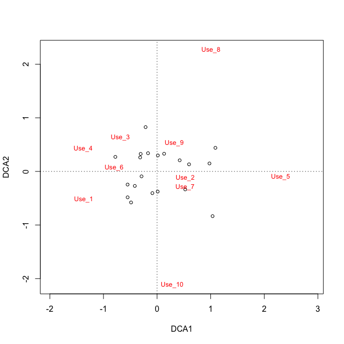

```r
#Plot ordination results
plot(ethno_ordination)
```

## Principal component analysis (PCA)

Principal component analysis (PCA) can be used to create sets of linearly uncorrelated variables from cases of informant-species-use associations. The resulting principal components are linear combinations of variables that are fed in and each contain all observations. We perform PCA using the `broom` (Robinson and Hayes 2019), `tidyr` (Wickham and Henry 2019) and `purrr` (Henry and Wickham 2019) packages using the `nest()` function along with the `mutate()` and `map()` functions to operate on the nested columns. This gives a `tibble` with one row and three columns: 1. our original data set, 2. the `prcomp` object and 3. a data frame of principal component values for each observation.

```r
nested_ethno_pca <- eb_data %>%
  tidyr::nest() %>%
  dplyr::mutate(pca = purrr::map(data, ~ stats::prcomp(.x %>%
        dplyr::select(-informant, -sp_name),
        center = TRUE, scale = TRUE)),
         pca_augmented = map2(pca, data, ~broom::augment(.x, data = .y)))
```

For PCA model evaluation we can check to see how much variance is explained by each principal component. This tells us how many of the components would be reasonable to assess when analyzing the results. To do this, we can use the data in the `pca_augmented` column of our `nested_ethno_pca` tibble along with `dplyr` (Wickham et al. 2019) and `magrittr` (Bache and Wickham 2014) functions.

```r
var_exp_tidy <- nested_ethno_pca %>%
  tidyr::unnest(pca_augmented) %>%
  dplyr::summarize_at(.vars = vars(contains("PC")), .funs = tibble::lst(var)) %>%
  tidyr::gather(key = pc, value = variance) %>%
  dplyr::mutate(var_exp = variance/sum(variance),
         cum_var_exp = cumsum(var_exp),
         pc = stringr::str_replace(pc, ".fitted", ""))
```

```r
var_exp <- var_exp_tidy %>%
  head(4)
```

Plot the variance explained and the cumulative variance explained to see trends across components.

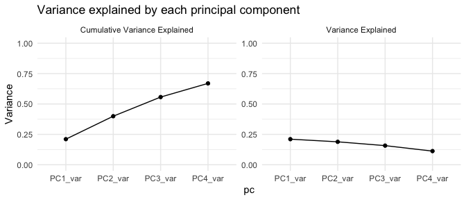

```r
var_exp %>%
  dplyr::rename(
    `Variance Explained` = var_exp,
    `Cumulative Variance Explained` = cum_var_exp
  ) %>%
  tidyr::gather(key = key, value = value, `Variance Explained`:`Cumulative Variance Explained`) %>%
  ggplot2::ggplot(ggplot2::aes(pc, value, group = key)) +
  ggplot2::geom_point() +
  ggplot2::geom_line() +
  ggplot2::facet_wrap(~key, scales = "free_y") +
  ggplot2::theme_minimal() +
  ggplot2::lims(y = c(0, 1)) +
  ggplot2::labs(y = "Variance",
       title = "Variance explained by each principal component")
```

## References

Albuquerque, Ulysses Paulino, Patricia Muniz de Medeiros, Washington Soares Ferreira Júnior, Taline Cristina da Silva, Rafael Ricardo Vasconcelos da Silva, and Thiago Gonçalves-Souza. 2019. “Social-Ecological Theory of Maximization: Basic Concepts and Two Initial Models.” *Biological Theory*, February. https://doi.org/10.1007/s13752-019-00316-8.

Bache, Stefan Milton, and Hadley Wickham. 2014. *Magrittr: A Forward-Pipe Operator for R*. https://CRAN.R-project.org/package=magrittr.

Cayuela, Luis, Anke Stein, and Jari Oksanen. 2017. *Taxonstand: Taxonomic Standardization of Plant Species Names*. https://CRAN.R-project.org/package=Taxonstand.

Gaoue, Orou G., Michael A. Coe, Matthew Bond, Georgia Hart, Barnabas C. Seyler, and Heather McMillen. 2017. “Theories and Major Hypotheses in Ethnobotany.” *Economic Botany* 71 (3): 269–87. https://doi.org/10.1007/s12231-017-9389-8.

Henry, Lionel, and Hadley Wickham. 2019. *Purrr: Functional Programming Tools*. https://CRAN.R-project.org/package=purrr.

Oksanen, Jari, F. Guillaume Blanchet, Michael Friendly, Roeland Kindt, Pierre Legendre, Dan McGlinn, Peter R. Minchin, et al. 2019. *Vegan: Community Ecology Package*. https://CRAN.R-project.org/package=vegan.

Robinson, David, and Alex Hayes. 2019. *Broom: Convert Statistical Analysis Objects into Tidy Tibbles*. https://CRAN.R-project.org/package=broom.

Wickham, Hadley, Romain François, Lionel Henry, and Kirill Müller. 2019. *Dplyr: A Grammar of Data Manipulation*. https://CRAN.R-project.org/package=dplyr.

Wickham, Hadley, and Lionel Henry. 2019. *Tidyr: Easily Tidy Data with ’Spread()’ and ’Gather()’ Functions*. https://CRAN.R-project.org/package=tidyr.